# HW5-f-kmeans

Mahtab and Amin

2024-12-04

I import the original data to R studio and use it. I did the following: # Specify the file and the sheet name or index # Read the specific sheet # View the data

```r
#install.packages("readxl")
library(readxl)
file_path <- "Champo_Carpets_Improving_Business_to_Business_Sales_Using_Machine.xlsx"
sheet_name <- "Data for Clustering"  # Replace with your sheet name or use sheet index, e.g., 1

data <- read_excel(file_path, sheet = sheet_name)


head(data)
```

```
## # A tibble: 6 × 14
##   `Row Labels` `Sum of QtyRequired` `Sum of TotalArea` `Sum of Amount` DURRY
##   <chr>                       <dbl>              <dbl>           <dbl> <dbl>
## 1 A-11                         2466               140.         185404.  1021
## 2 A-6                           131              2086            6247.     0
## 3 A-9                         18923             53626.        1592080.  3585
## 4 B-2                           624               203.          14811.   581
## 5 B-3                           464              8452.          58627.     0
## 6 B-4                           692              3244.          26242.    80
## # ℹ 9 more variables: HANDLOOM <dbl>, `DOUBLE BACK` <dbl>, JACQUARD <dbl>,
## #   `HAND TUFTED` <dbl>, `HAND WOVEN` <dbl>, KNOTTED <dbl>, `GUN TUFTED` <dbl>,
## #   `Powerloom Jacquard` <dbl>, `INDO TEBETAN` <dbl>
```

```r
str(data)
```

```
## tibble [45 × 14] (S3: tbl_df/tbl/data.frame)
##  $ Row Labels        : chr [1:45] "A-11" "A-6" "A-9" "B-2" ...
##  $ Sum of QtyRequired: num [1:45] 2466 131 18923 624 464 ...
##  $ Sum of TotalArea  : num [1:45] 140 2086 53626 203 8452 ...
##  $ Sum of Amount     : num [1:45] 185404 6247 1592080 14811 58627 ...
##  $ DURRY             : num [1:45] 1021 0 3585 581 0 ...
##  $ HANDLOOM          : num [1:45] 1445 0 0 0 0 ...
##  $ DOUBLE BACK       : num [1:45] 0 25 175 0 459 0 0 0 0 3 ...
##  $ JACQUARD          : num [1:45] 0 106 714 2 5 0 0 0 0 0 ...
##  $ HAND TUFTED       : num [1:45] 0 0 11716 0 0 ...
##  $ HAND WOVEN        : num [1:45] 0 0 2116 41 0 ...
##  $ KNOTTED           : num [1:45] 0 0 617 0 0 0 453 0 0 0 ...
##  $ GUN TUFTED        : num [1:45] 0 0 0 0 0 0 0 0 0 19 ...
##  $ Powerloom Jacquard: num [1:45] 0 0 0 0 0 0 0 0 0 0 ...
##  $ INDO TEBETAN      : num [1:45] 0 0 0 0 0 0 0 0 0 0 ...
```

#missing values I checked for missing values but there were no missing values to delet.

```r
 sum(is.na(data))
```

```
## [1] 0
```

there is no missing value

#normalize for k-means it is neccessary to normalize the data so that none of the variables dominant the distane similarity. I used min-max for that.

```r
library(dplyr)
myscale <- function(x) {
(x - min(x)) / (max(x) - min(x))
}
Data <- data %>% mutate_if(is.numeric, myscale)

head(Data)
```

```
## # A tibble: 6 × 14
##   `Row Labels` `Sum of QtyRequired` `Sum of TotalArea` `Sum of Amount`    DURRY
##   <chr>                       <dbl>              <dbl>           <dbl>    <dbl>
## 1 A-11                     0.0134             0.000659        0.0163   0.00731
## 2 A-6                      0.000704           0.00994         0.000522 0
## 3 A-9                      0.103              0.256           0.140    0.0257
## 4 B-2                      0.00340            0.000961        0.00128  0.00416
## 5 B-3                      0.00252            0.0403          0.00514  0
## 6 B-4                      0.00377            0.0155          0.00229  0.000573
## # ℹ 9 more variables: HANDLOOM <dbl>, `DOUBLE BACK` <dbl>, JACQUARD <dbl>,
## #   `HAND TUFTED` <dbl>, `HAND WOVEN` <dbl>, KNOTTED <dbl>, `GUN TUFTED` <dbl>,
## #   `Powerloom Jacquard` <dbl>, `INDO TEBETAN` <dbl>
```

#outlier at first, I was trying to remove the outliers from the data but for some coloumns that are related to dummy variables it will delet the only 1 in the whole colomn as the outlier. So I decided not to delet the outliers regarding the dataset nature and commented all codes for it.

```r
#out_lier <- function(x) {
#  if (is.numeric(x)) {
#    q1 <- quantile(x, 0.25, na.rm = TRUE)
#    q3 <- quantile(x, 0.75, na.rm = TRUE)
#    IQR_val <- q3 - q1
#    lower <- q1 - 1.5*IQR_val
#    upper <- q3 + 1.5*IQR_val
#    return(x < lower | x > upper) # Directly return the logical vector
#  } else {
#    return(rep(FALSE, length(x))) # No outliers for non-numeric data
#  }
#}
#
#
#data_no_out <- Data %>%
#  mutate(across(where(is.numeric), ~ ifelse(out_lier(.), median(., na.rm = TRUE), .)))
#
#sum_outliers <- sum(sapply(data_no_out %>% select(where(is.numeric)), function(col) sum(out_lier(col))))
#
#sum_outliers
```

#making it a data frame and also deleting the labels: I converted the data set to a data frame and also deleted first colomn which are the labels for each instance and are not numerical and we can just delet this colomn.

```r
df <- as.data.frame(Data)
dfi <- df[-1]
any(is.na(dfi))    # Checks for NA
```

```
## [1] FALSE
```

```r
#any(is.nan(dfi))   # Checks for NaN
#any(is.infinite(dfi)) # Checks for Inf or -Inf
str(dfi)
```

```
## 'data.frame':    45 obs. of  13 variables:
##  $ Sum of QtyRequired: num  0.013449 0.000704 0.103278 0.003395 0.002522 ...
##  $ Sum of TotalArea  : num  0.000659 0.00994 0.25569 0.000961 0.040292 ...
##  $ Sum of Amount     : num  0.01632 0.000522 0.140357 0.001277 0.005141 ...
##  $ DURRY             : num  0.00731 0 0.02568 0.00416 0 ...
##  $ HANDLOOM          : num  0.393 0 0 0 0 ...
##  $ DOUBLE BACK       : num  0 0.0046 0.0322 0 0.0844 ...
##  $ JACQUARD          : num  0 0.1485 1 0.0028 0.007 ...
##  $ HAND TUFTED       : num  0 0 0.193 0 0 ...
##  $ HAND WOVEN        : num  0 0 0.14783 0.00286 0 ...
##  $ KNOTTED           : num  0 0 0.0649 0 0 ...
##  $ GUN TUFTED        : num  0 0 0 0 0 ...
##  $ Powerloom Jacquard: num  0 0 0 0 0 0 0 0 0 0 ...
##  $ INDO TEBETAN      : num  0 0 0 0 0 0 0 0 0 0 ...
```

#kmeans models at first I just tried to implement the kmeans with 2 clusters but in the following I will find the best number of clusters.

```r
kModel1 <- kmeans(dfi , centers = 2, nstart = 100)

kModel1
```

```
## K-means clustering with 2 clusters of sizes 3, 42
##
## Cluster means:
##   Sum of QtyRequired Sum of TotalArea Sum of Amount      DURRY   HANDLOOM
## 1         0.45163133       0.49095247    0.25954037 0.39638394 0.44432344
## 2         0.04362532       0.03162803    0.04739456 0.02619529 0.02238342
##   DOUBLE BACK  JACQUARD HAND TUFTED HAND WOVEN     KNOTTED GUN TUFTED
## 1  0.62082491 0.4495798  0.17390898 0.26605654 0.460534624 0.33333333
## 2  0.03600977 0.1020742  0.05203569 0.04594403 0.008346614 0.02087912
##   Powerloom Jacquard INDO TEBETAN
## 1          0.3333333   0.00000000
## 2          0.0000000   0.03809524
##
## Clustering vector:
##  [1] 2 2 2 2 2 2 2 2 2 2 2 2 2 2 2 2 2 2 1 2 2 2 2 2 2 2 2 1 2 2 2 1 2 2 2 2 2 2
## [39] 2 2 2 2 2 2 2
##
## Within cluster sum of squares by cluster:
## [1] 4.760036 8.237222
##  (between_SS / total_SS =  26.6 %)
##
## Available components:
##
## [1] "cluster"      "centers"      "totss"        "withinss"     "tot.withinss"
## [6] "betweenss"    "size"         "iter"         "ifault"
```

```r
library(factoextra)
```

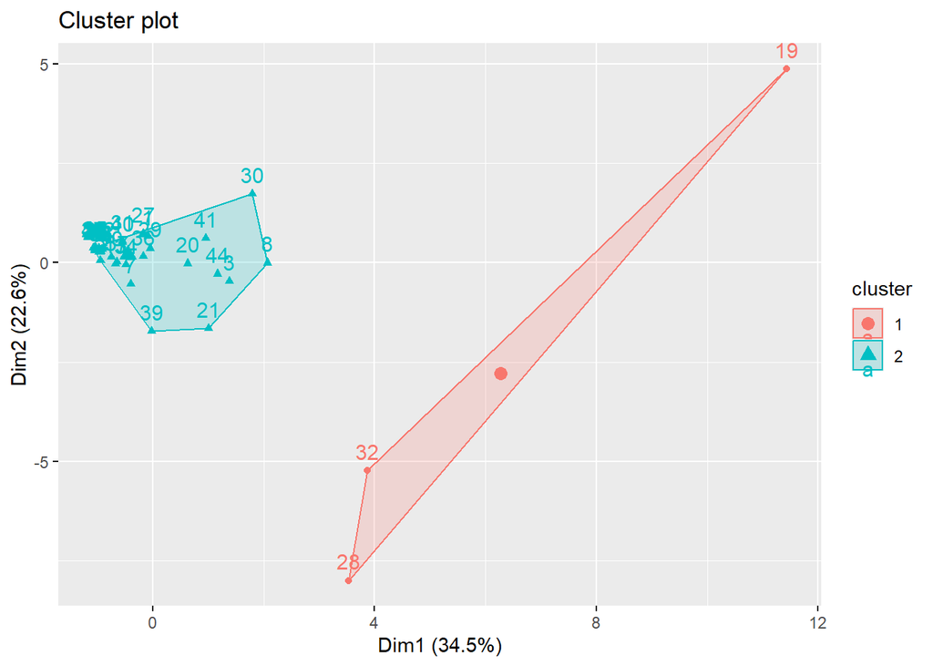

```r
fviz_cluster(kModel1, dfi)
```

#now I try different cluster numbers for visualization.

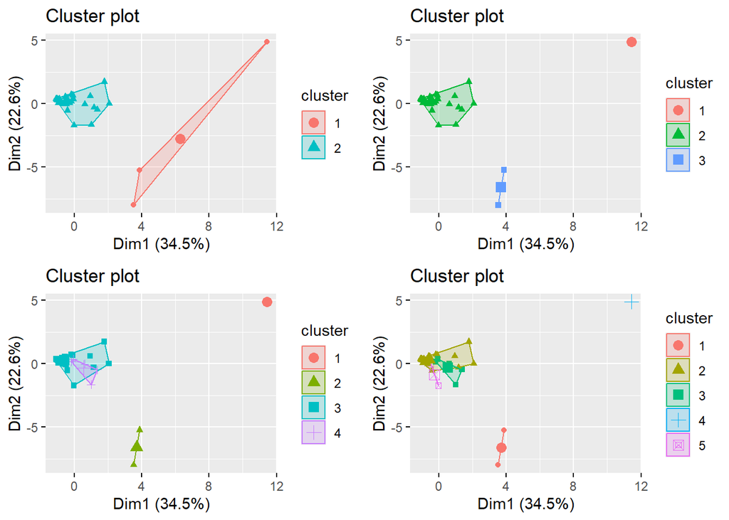

```r
kModel2 <- kmeans(dfi , centers = 2, nstart = 100)
kModel3 <- kmeans(dfi , centers = 3, nstart = 100)
kModel4 <- kmeans(dfi , centers = 4, nstart = 100)
kModel5 <- kmeans(dfi , centers = 5, nstart = 100)


fp2 <- fviz_cluster(kModel2, dfi, geom = "point")
fp3 <- fviz_cluster(kModel3, dfi, geom = "point")
fp4 <- fviz_cluster(kModel4, dfi, geom = "point")
fp5 <- fviz_cluster(kModel5, dfi, geom = "point")

library(gridExtra)
grid.arrange(fp2, fp3, fp4, fp5, nrow = 2)
```

#in the following code we can use scree plot and elbow method to find the best K. with WSS

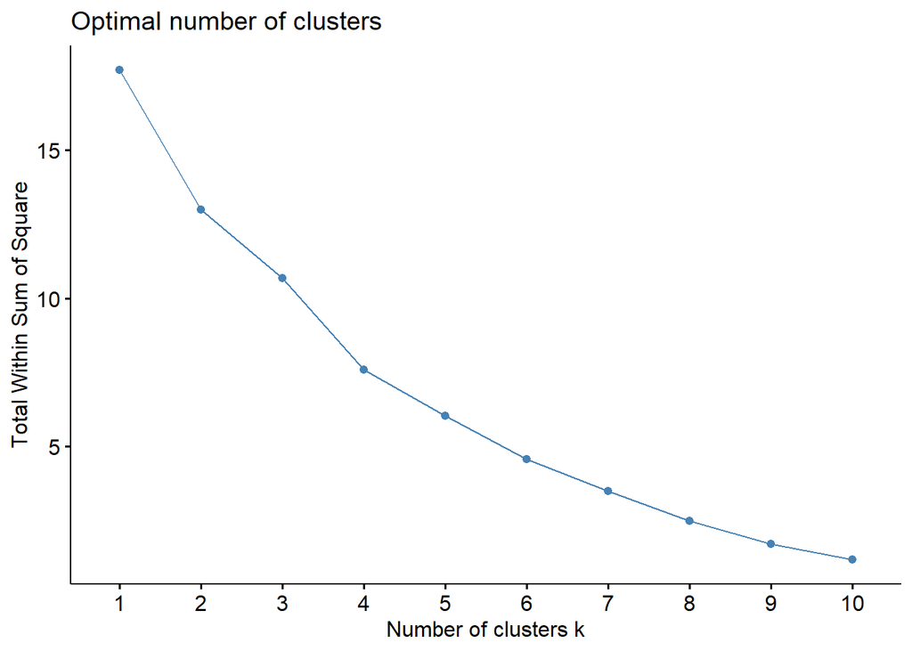

```r
set.seed(123)
fviz_nbclust(dfi , kmeans, method = "wss")
```

#in the following code we can use Silloutee to find the best K.

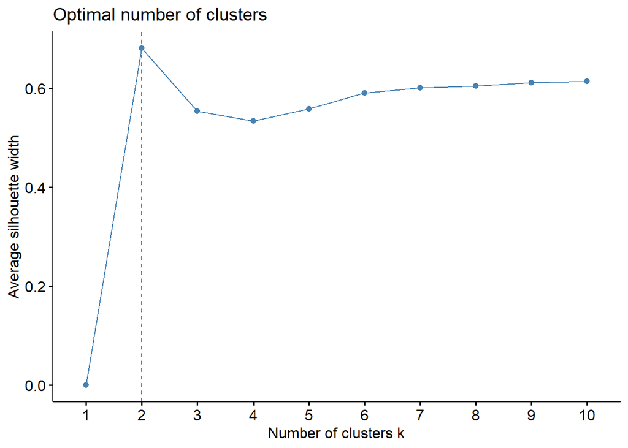

```r
set.seed(123)
fviz_nbclust(dfi , kmeans, method = "silhouette")
```

```r
library(cluster)
avg_sil <- function(k){
  kModel1 <- kmeans(dfi, centers = k , nstart = 100)
  ss <- silhouette(kModel1$cluster , dist(dfi))
  mean(ss[,3])
}


avg_sil(2)
```

```
## [1] 0.6804853
```

```r
avg_sil(3)
```

```
## [1] 0.6712839
```

```r
avg_sil(4)
```

```
## [1] 0.5041119
```

```r
avg_sil(6)
```

```
## [1] 0.5906622
```

#As we can see 2 clusters are the best regarding silhouette

```r
cluster_summary <- df %>%
  mutate(Cluster = kModel2$cluster) %>%
  group_by(Cluster) %>%
  summarise(across(everything(), mean))
print(cluster_summary)
```

```
## # A tibble: 2 × 15
##   Cluster `Row Labels` `Sum of QtyRequired` `Sum of TotalArea` `Sum of Amount`
##     <int>        <dbl>                <dbl>              <dbl>           <dbl>
## 1       1           NA               0.452              0.491           0.260
## 2       2           NA               0.0436             0.0316          0.0474
## # ℹ 10 more variables: DURRY <dbl>, HANDLOOM <dbl>, `DOUBLE BACK` <dbl>,
## #   JACQUARD <dbl>, `HAND TUFTED` <dbl>, `HAND WOVEN` <dbl>, KNOTTED <dbl>,
## #   `GUN TUFTED` <dbl>, `Powerloom Jacquard` <dbl>, `INDO TEBETAN` <dbl>
```

```r
library(GGally)
```

[figure not shown]

```r
ggpairs(dfi, aes(color = factor(kModel2$cluster)))
```

#the cluster characteristics summarized by the mean values of the variables for each cluster.

Develop loyalty programs or promotional campaigns to encourage repeat purchases and higher order volumes. Offer educational or promotional materials highlighting the benefits of other product categories to expand their buying preferences.

#part g

#recommender system:

I used cosine similarity to find n nearest neighbors for a target costumer. to create a customer-product purchase matrix, I deleted coloumns 2 to 4 and only keep row labels whcih is first column and also the numbers for each product type which are in columns 5 to end. Parameters: purchase_matrix: Customer-product matrix (rows: customers, cols: products, values: purchase counts or binary) target_customer: ID of the target customer (row name in the matrix) top_n_neighbors: Number of nearest neighbors to consider

```r
library(proxy)
fil_recommender <- function(purchase_matrix, target_customer, top_n_neighbors = 3) {

  rownames(purchase_matrix) <- purchase_matrix$Customer

#Cosine Similarity
  similarity_matrix <- as.matrix(simil(purchase_matrix[-1], method = "cosine"))

  #Exclude Self-Similarity
  diag(similarity_matrix) <- NA

  neighbors <- sort(similarity_matrix[target_customer, ], decreasing = TRUE, na.last = TRUE)
  nearest_neighbors <- head(names(neighbors), top_n_neighbors)

#Aggregate Product Purchases of Nearest Neighbors
  neighbors_purchases <- purchase_matrix[nearest_neighbors, -1, drop = FALSE]  # Exclude Customer column
  aggregated_purchases <- colSums(neighbors_purchases, na.rm = TRUE)

# Filter Out Products Already Purchased by the target Customer
  target_customer_purchases <- purchase_matrix[target_customer, -1]
  recommendations <- aggregated_purchases[target_customer_purchases == 0]

  recommendations <- sort(recommendations, decreasing = TRUE)

  return(recommendations)
}


#to create a customer-product purchase matrix. I deleted coloumns 2 to 4 and only keep row labels whcih is first column and also the numbers for each product type which are in columns 5 to end.

data_rec <- df[, -c(2:4)]
purchase_matrix <- data.frame(data_rec)
colnames(purchase_matrix)[1] <- "Customer"  # Rename the first column to "Customer"

recommendations <- fil_recommender(purchase_matrix, target_customer = "A-11", top_n_neighbors = 2)


print(recommendations)
```

```
##        HAND.TUFTED        DOUBLE.BACK           JACQUARD         HAND.WOVEN
##         0.06883085         0.00000000         0.00000000         0.00000000
##            KNOTTED         GUN.TUFTED Powerloom.Jacquard       INDO.TEBETAN
##         0.00000000         0.00000000         0.00000000         0.00000000
```